# Analysis of Contributions towards Presidential Campaign in 2016 in California

# by Rajat Gupta

This dataset looks at the Financial Contributions made to the presidential campaign for the U.S. presidential election in 2016 in the State of California. The data is provided by the Federal Election Commission and includes information about the donor, the amount contributed and the receiving candidate. Extra information about the individual’s party affiliation and gender have also been added.

# Univariate Plots Section

Looking at the Data, the variables within it,

```
## [1] 1304346      20
```

```
## 'data.frame':    1304346 obs. of  20 variables:
##  $ cmte_id          : chr  "C00575795" "C00575795" "C00575795" "C00580100" ...
##  $ cand_id          : Factor w/ 25 levels "P00003392","P20002671",..: 1 1 1 23 12 23 12 12 12 1 ...
##  $ cand_nm          : Factor w/ 25 levels "Bush, Jeb","Carson, Benjamin S.",..: 4 4 4 23 20 23 20 20 20 4 ...
##  $ contbr_nm        : Factor w/ 231294 levels "'CALL, BARBARA",..: 7753 31629 70312 175051 117924 176417 119377 119377 119411 92354 ...
##  $ contbr_city      : Factor w/ 2534 levels "","-4086","#NAME?",..: 1136 324 729 1183 323 1913 1810 1810 2402 1094 ...
##  $ contbr_st        : Factor w/ 1 level "CA": 1 1 1 1 1 1 1 1 1 1 ...
##  $ contbr_zip       : Factor w/ 143656 levels "","00000","000090272",..: 115155 71795 53864 126927 66455 139488 17327 17327 45924 58804 ...
##  $ contbr_employer  : Factor w/ 65585 levels "''RETIRED''",..: 38790 38790 38790 27606 4489 27606 62101 62101 41402 38790 ...
##  $ contbr_occupation: Factor w/ 28622 levels "","''RETIRED''",..: 21476 21476 21476 12737 23942 12737 17980 17980 19679 21476 ...
##  $ contb_receipt_amt: num  50 200 5 48.3 40 ...
##  $ contb_receipt_dt : Factor w/ 732 levels "01-APR-15","01-APR-16",..: 596 446 27 486 85 564 108 132 85 446 ...
##  $ receipt_desc     : Factor w/ 74 levels "","* EARMARKED CONTRIBUTION: SEE BELOW REATTRIBUTION/REFUND PENDING",..: 1 1 1 1 1 1 1 1 1 1 ...
##  $ memo_cd          : Factor w/ 2 levels "","X": 2 2 2 2 1 2 1 1 1 2 ...
##  $ memo_text        : Factor w/ 428 levels "","$0.02 REFUNDED ON 10/21/2016",..: 126 126 126 1 90 1 90 90 90 126 ...
##  $ form_tp          : Factor w/ 3 levels "SA17A","SA18",..: 2 2 2 2 1 2 1 1 1 2 ...
##  $ file_num         : int  1091718 1091718 1091718 1146165 1077404 1146165 1077404 1077404 1077404 1091718 ...
##  $ tran_id          : Factor w/ 1300659 levels "A000771210424405B8CF",..: 466737 466019 463401 852428 1037145 890506 1038589 1040890 1036607 466057 ...
##  $ election_tp      : Factor w/ 5 levels "","G2016","O2016",..: 4 4 4 2 4 2 4 4 4 4 ...
##  $ pol_party        : Factor w/ 3 levels "Democratic Party",..: 1 1 1 3 1 3 1 1 1 1 ...
##  $ gender           : Factor w/ 2 levels "Female","Male": 1 1 1 2 2 2 2 2 2 1 ...
```

```
##    cmte_id               cand_id                            cand_nm
##  Length:1304346     P00003392:688524   Clinton, Hillary Rodham  :688524
##  Class :character   P60007168:407164   Sanders, Bernard         :407164
##  Mode  :character   P80001571: 86258   Trump, Donald J.         : 86258
##                     P60006111: 57822   Cruz, Rafael Edward 'Ted': 57822
##                     P60005915: 27370   Carson, Benjamin S.      : 27370
##                     P60006723: 14095   Rubio, Marco             : 14095
##                     (Other)  : 23113   (Other)                  : 23113
##             contbr_nm              contbr_city     contbr_st
##  PETIT, MICHAEL  :    473   LOS ANGELES  :102710   CA:1304346
##  MITCHELL, MARCIA:    409   SAN FRANCISCO: 90937
##  SMITH, CHERYL   :    375   SAN DIEGO    : 46129
##  SAMATUA, DENISE :    373   OAKLAND      : 33235
##  CARROLL, TERI   :    352   SAN JOSE     : 30674
##  ADAM, MONIQUE   :    321   SACRAMENTO   : 23799
##  (Other)         :1302043   (Other)      :976862
##      contbr_zip           contbr_employer               contbr_occupation
##  92660    :    660   SELF EMPLOYED:196618   RETIRED              :260546
##  92037    :    565   N/A          :195904   NOT EMPLOYED         :115598
##  90049    :    495   RETIRED      :121569   ATTORNEY             : 36640
##  92677    :    483   NONE         : 84297   INFORMATION REQUESTED: 30948
##  92067    :    474   NOT EMPLOYED : 51685   TEACHER              : 29104
##  911075001:    473   (Other)      :653594   (Other)              :831369
##  (Other)  :1301196   NA's         :   679   NA's                 :   141
##  contb_receipt_amt   contb_receipt_dt
##  Min.   :-10500.0   29-FEB-16:  11735
##  1st Qu.:    15.0   31-MAR-16:  11506
##  Median :    27.0   31-MAY-16:  10435
##  Mean   :   116.2   31-OCT-16:  10220
##  3rd Qu.:    88.0   06-NOV-16:  10199
##  Max.   : 10800.0   01-NOV-16:  10082
##                     (Other)  :1240169
##                                   receipt_desc     memo_cd
##                                         :1287456    :1104791
##  Refund                                 :  10413   X: 199555
##  REDESIGNATION FROM PRIMARY             :   1324
##  REDESIGNATION TO GENERAL               :   1324
##  REATTRIBUTION / REDESIGNATION REQUESTED:    569
##  REDESIGNATION TO CRUZ FOR SENATE       :    544
##  (Other)                                :   2716
```

[output cut: 9 more lines]

```
##  Min.   :1003942   A5602AD777C8C4632B5A:      4        :  1695
##  1st Qu.:1077916   ADB49CB248C174E298F0:      4   G2016:483991
##  Median :1099613   A26C35A6066754130B99:      3   O2016:   632
##  Mean   :1102796   A340DF85B7F884133A20:      3   P2016:818021
##  3rd Qu.:1133832   A4E50E2DD07E4475996F:      3   P2020:     7
##  Max.   :1146285   A7C22FA389E0348F98F0:      3
##                    (Other)             :1304326
##             pol_party          gender
##  Democratic Party:1096563   Female:696072
##  Other           :   4906   Male  :608274
##  Republican Party: 202877
##
##
##
##
```

Now, looking at variation in different variables,

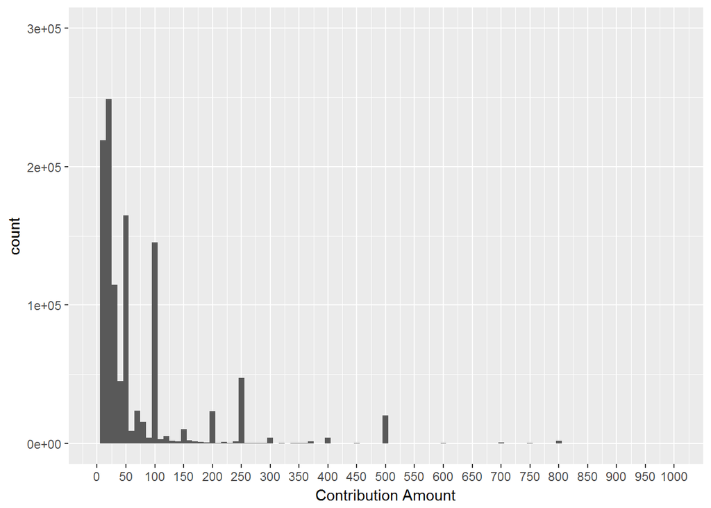

```
##     Min.  1st Qu.   Median     Mean  3rd Qu.     Max.
##     0.01    15.00    27.00   123.15    99.00 10800.00
```

We can clearly see that most of the donations made are small amounts, with very few large donations.

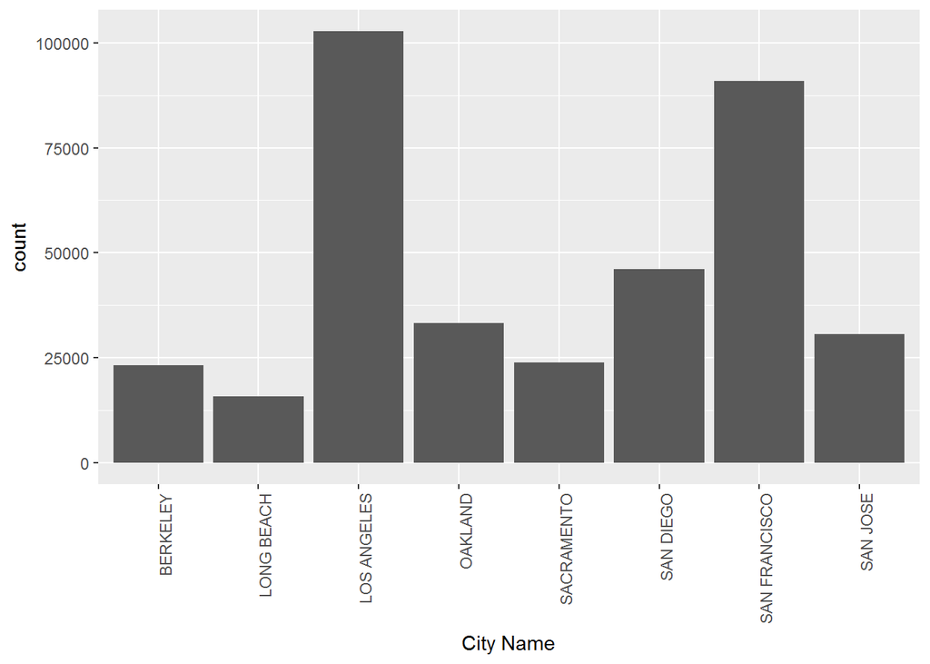

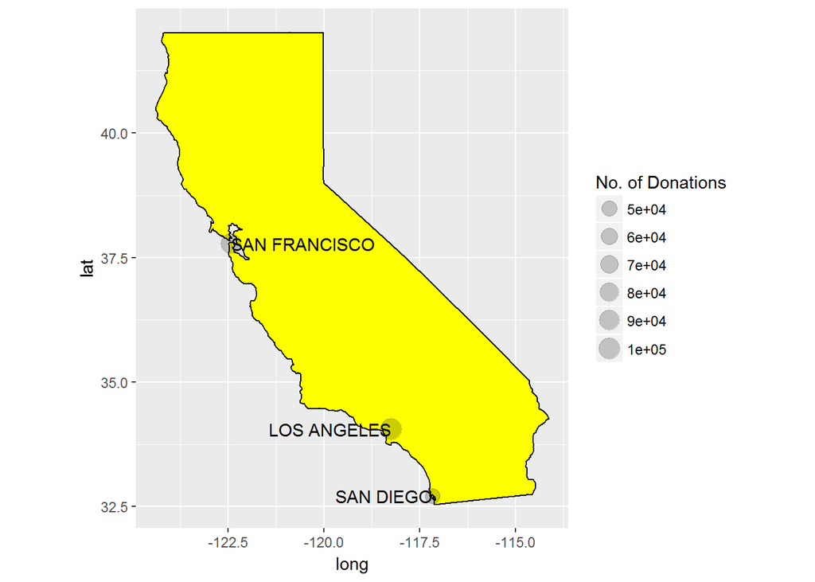

```
##   LOS ANGELES SAN FRANCISCO     SAN DIEGO       OAKLAND      SAN JOSE
##        102710         90937         46129         33235         30674
##    SACRAMENTO      BERKELEY    LONG BEACH       (Other)
##         23799         23150         15757        475466
```

We can see that the largest number of the contributions are coming from cities located on the California coast (Los Angeles, San Francisco & San Diego).

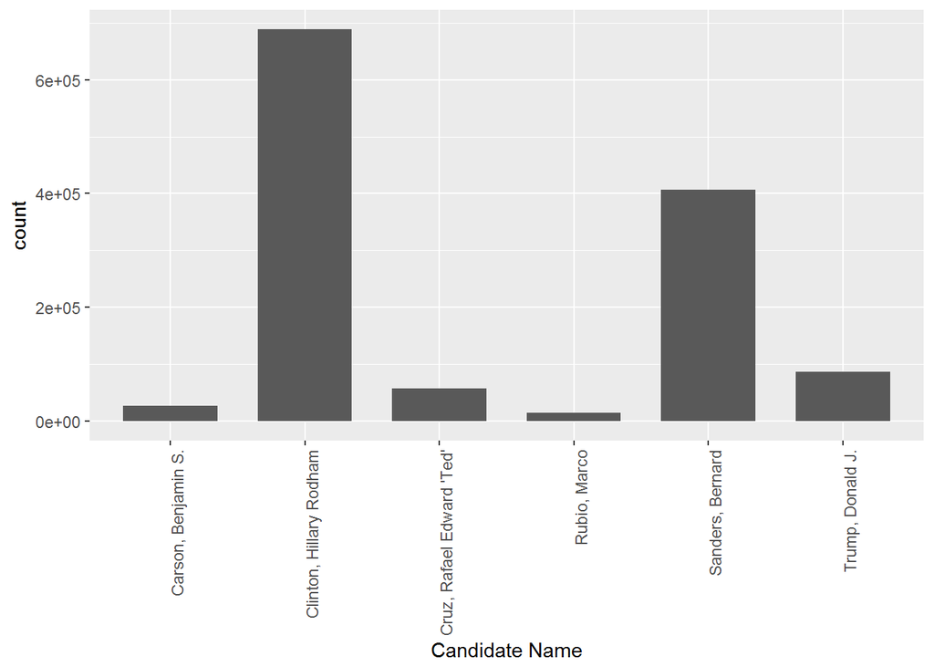

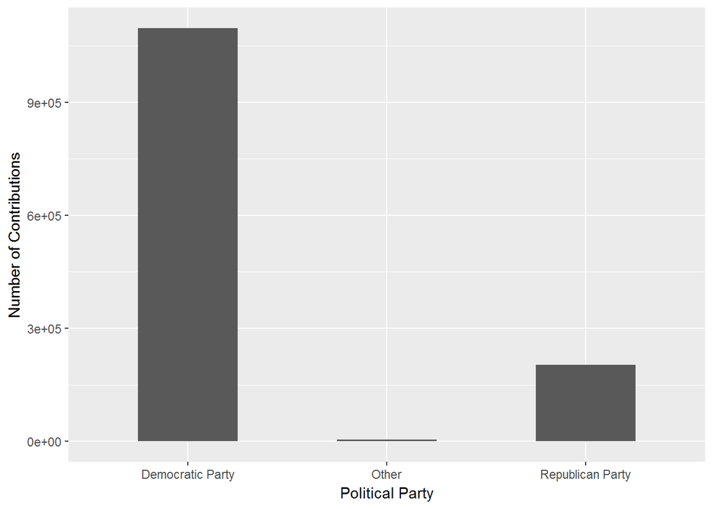

As the candidates who got the most donations were affiliated with the Democratic Party, it is no surprise that their party had the largest number of contributions in the state of California.

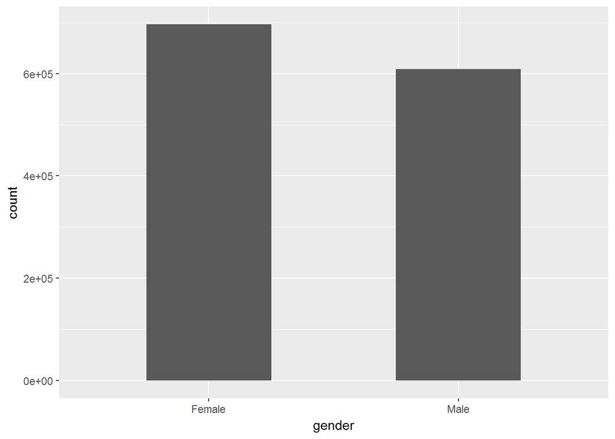

We can see that Female candidates received greater number of donations than their male counterparts.

Lets, look at the employers for the donating individuals.

```
## [1] "Donor Occupation information"
```

```
##               RETIRED          NOT EMPLOYED              ATTORNEY
##                260546                115598                 36640
## INFORMATION REQUESTED               TEACHER              ENGINEER
##                 30948                 29104                 17749
```

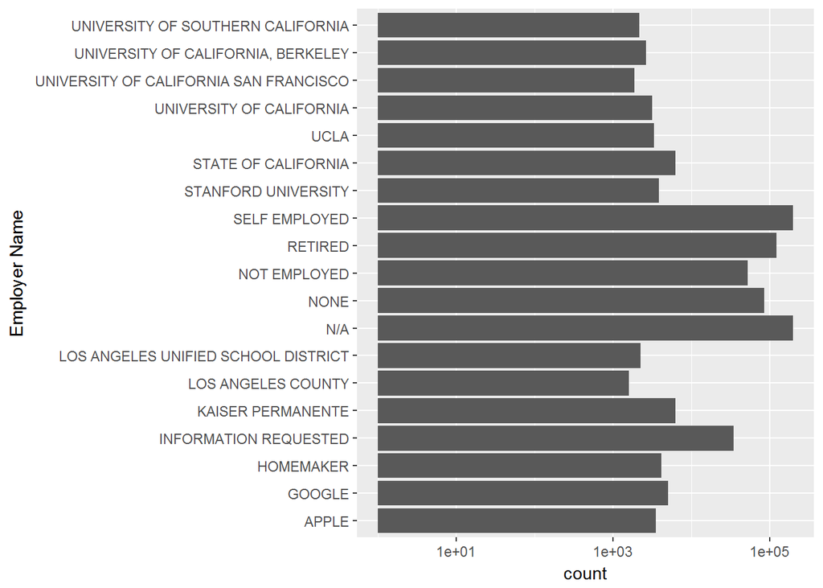

We can see that most of the individuals that contributed financially are either Self Employed, retired or the data is unavailable. The above graph has been created after extensive data cleaning because of abbreviations and empty cell values which have been renamed N/A due to lack of knowledge.

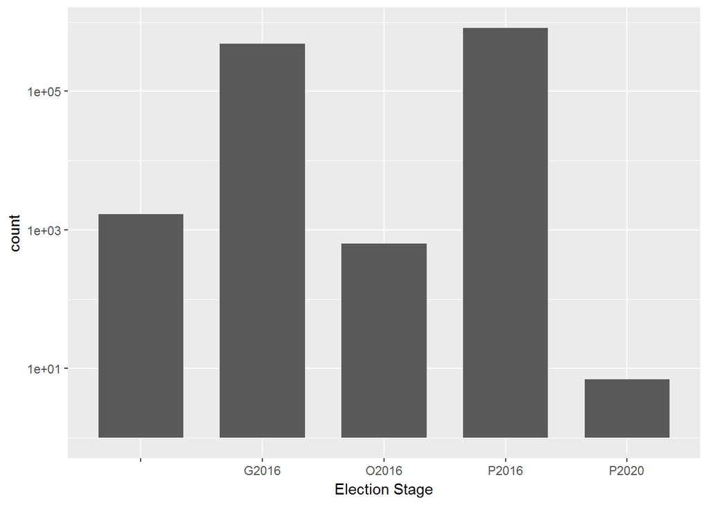

While analysing, the stages at which the donations were made, we see that the column “election_tp” has 1695 empty entries. There are also 10548 empty entries in the column, “contbr_employer”.

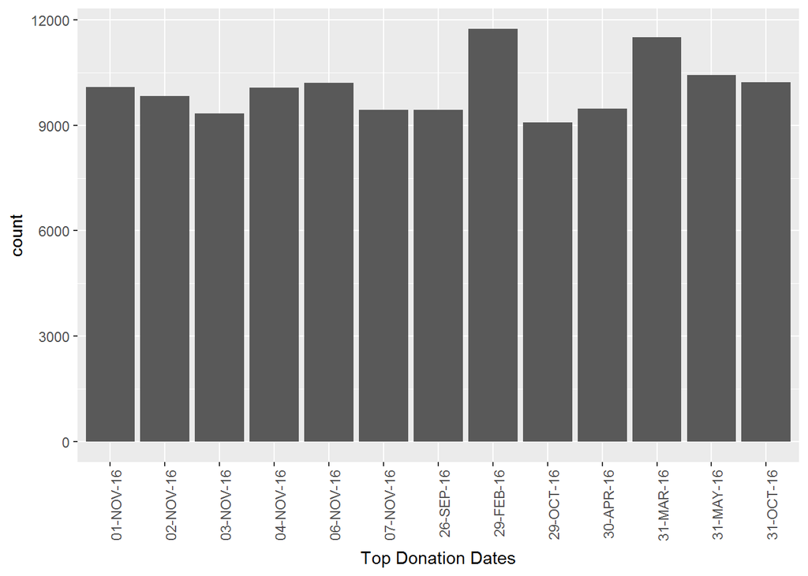

```
##  [1] "29-FEB-16" "31-MAR-16" "31-MAY-16" "31-OCT-16" "06-NOV-16"
##  [6] "01-NOV-16" "04-NOV-16" "02-NOV-16" "30-APR-16" "26-SEP-16"
## [11] "07-NOV-16" "03-NOV-16" "29-OCT-16" "(Other)"
```

We find that most of the donations were either made in the months of October and Novemeber, close to the General Election in the country or during the months of March and April, before the Primary Election in Califronia.

# Univariate Analysis

### What is/are the main feature(s) of interest in your dataset?

The main features of interest involve looking at the relation between the amount donated, number of contibutions and the characterstics (occupation, employer) of the donor. It will also be interesting looking at different candidates and analysing the sources of their donations.

### What other features in the dataset do you think will help support your investigation into your feature(s) of interest?

The information about party affiliation, candidate gender, contributed amount, time at which the contribution was made, all lend themselves to the analysis being performed and will help in determining if any correlation exists between different variables.

### Did you create any new variables from existing variables in the dataset?

Two new variables describing the party affiliation and the gender of the candidate were added to help in analysing the data. Data for the creation of both the variables was achieved through the Wikipedia page for each of the candidates.

This data is required to analyse the variation in donations made according to the party affiliation and candidate gender to determine possible donor preferences.

### Of the features you investigated, were there any unusual distributions? Did you perform any operations on the data to tidy, adjust, or change the form of the data? If so, why did you do this?

The data has a lot of empty entries specially in the election_tp, contbr_employer variables.

The variable, contbr_employer was cleaned to care of over abbreviated employer names and empty values. However, ‘complete’ cleaning was not possible due to high number of records and presence of unique entries each following a different standard.

Also, while analysing the amount contributed, only values with positive contb_receipt_amt were considered because a negative value represented a refund made back to the donor which doesn’t reflect a donation.

# Bivariate Plots Section

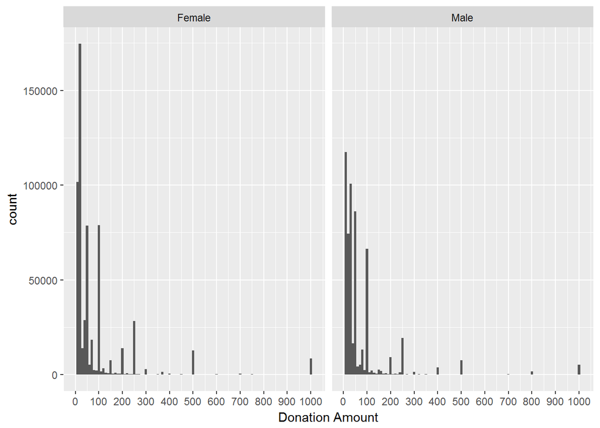

```
## subset(Data, contb_receipt_amt > 0)$gender: Female
##     Min.  1st Qu.   Median     Mean  3rd Qu.     Max.
##     0.01    15.00    25.00   141.53   100.00 10000.00
## --------------------------------------------------------
## subset(Data, contb_receipt_amt > 0)$gender: Male
##     Min.  1st Qu.   Median     Mean  3rd Qu.     Max.
##     0.01    15.00    28.00   102.01    80.00 10800.00
```

It is interesting to note that although, the maximum & median donation made to male candidates was greater than that for female candidates, the mean donation made to the female candidates was higher, this could be due to a large number of high donations made to female candidates compared to their male counterparts. Let’s verify this by looking at donations greater that $1000.

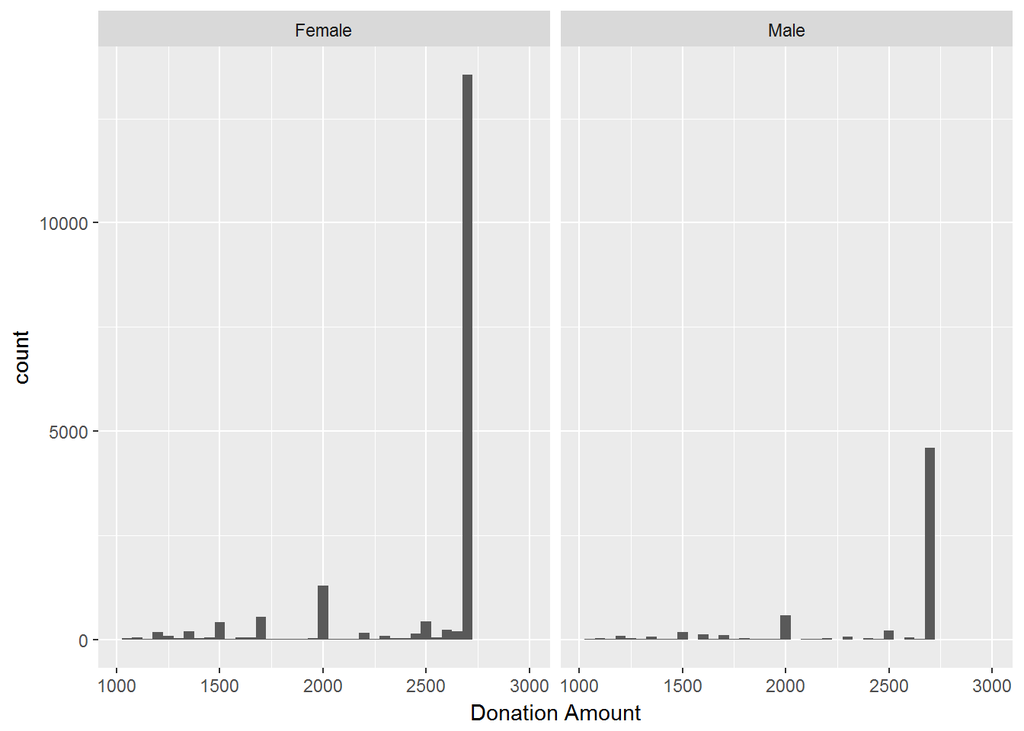

It was interesting to note that there appeared to be a spike in donations made near $3000 for both male and female candidates, but this spike is greater for female candidates than for male candidates, which would explain the higher mean value for female candidates.

Let’s look at which Female candidates is receiving these donations,

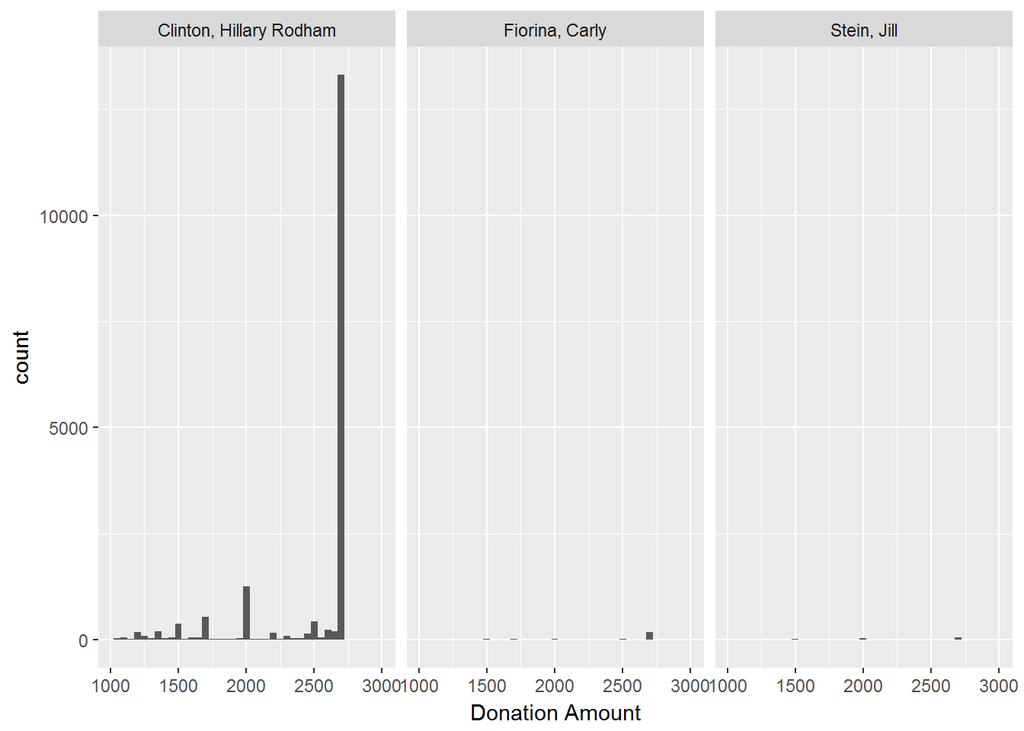

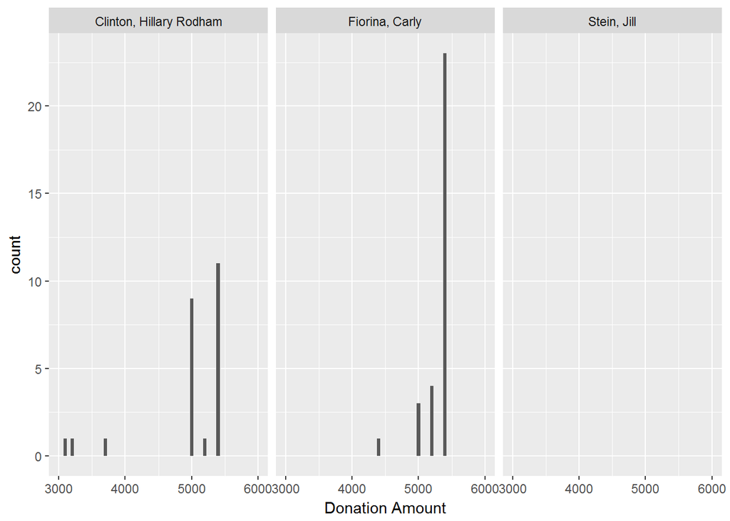

It is interesting to see from these graphs that “Clinton, Hillary Rodham” recieved much greater donations between 2500 and 3000 than rest of the female candidates. But, “Fiorina, Carly” received greater number of donations ranging from 5000-6000$. As we see that the number of donations received by “Clinton, Hillary Rodham” were much greater than others, she received the most donations among female candidates.

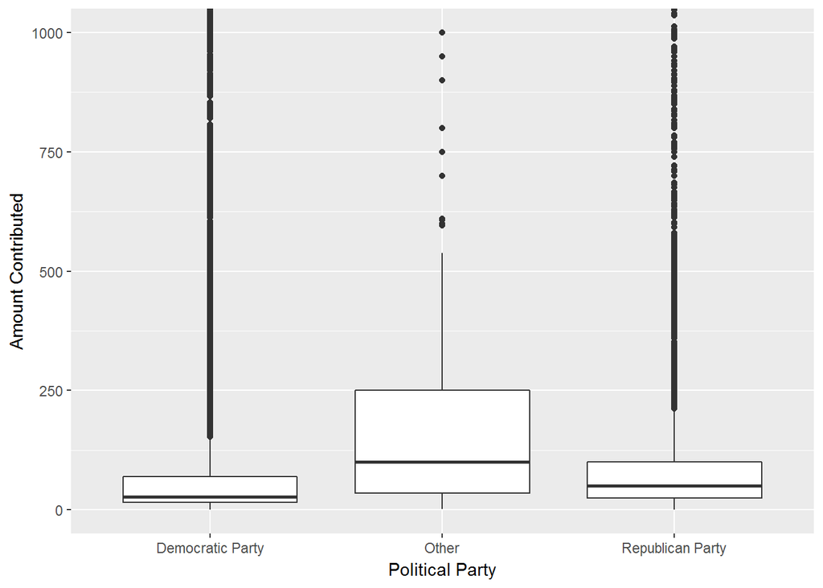

```
## subset(Data, contb_receipt_amt > 0)$pol_party: Democratic Party
##     Min.  1st Qu.   Median     Mean  3rd Qu.     Max.
##     0.01    15.00    27.00   107.17    70.00 10000.00
## --------------------------------------------------------
## subset(Data, contb_receipt_amt > 0)$pol_party: Other
##    Min. 1st Qu.  Median    Mean 3rd Qu.    Max.
##     1.0    35.0   100.0   265.3   250.0  5000.0
## --------------------------------------------------------
## subset(Data, contb_receipt_amt > 0)$pol_party: Republican Party
##     Min.  1st Qu.   Median     Mean  3rd Qu.     Max.
##     0.01    25.00    50.00   207.91   100.00 10800.00
```

This verifies the boxplots achieved, telling us that although the Democratic Party received greater number of donations (from Univariate Analaysis), the Republican and the other parties received a higher mean and median contribution amount per donor.

Lets look at the Individuals who have made the highest single contributions to the campaigns,

```
## [1] "Occupation of Top Paying Individuals:"
```

```
##                                    CEO
##                                     11
##                              PRESIDENT
##                                      7
## INFORMATION REQUESTED PER BEST EFFORTS
##                                      6
##                                RETIRED
##                                      6
##                                  OWNER
##                                      4
##       CLINICAL PROFESSOR OF PEDIATRICS
##                                      2
##                                    CPA
##                                      2
##                        FOUNDER AND CEO
##                                      2
##                 FREE LANCE HOME SITTER
##                                      2
##                  INFORMATION REQUESTED
##                                      2
##                            INVESTMENTS
##                                      2
##                                   M.D.
##                                      2
##                                ACTRESS
##                                      1
##                         CHAIRMAN & CEO
##                                      1
##                       CHAIRMAN AND CEO
##                                      1
##                             CONTRACTOR
##                                      1
##                         CORP EXECUTIVE
##                                      1
##                             LANDSCAPER
##                                      1
##                                MANAGER
##                                      1
##                         MEDICAL DOCTOR
##                                      1
##                                PARTNER
##                                      1
##                        PRESIDENT & CEO
##                                      1
##                REAL ESTATE INVESTMENTS
##                                      1
##                   REAL ESTATE INVESTOR
##                                      1
##                                STUDENT
##                                      1
```

```
## [1] "Organizations Top Paying Individuals work for:"
```

```
##                          SELF EMPLOYED
##                                      9
##                  INFORMATION REQUESTED
##                                      8
##                                RETIRED
##                                      6
##                               ILLUMINA
##                                      3
##                BARAK; RICHTER AND DROR
##                                      2
##                  CKE RESTAURANTS; INC.
##                                      2
##                           CORDARY; INC
##                                      2
##                           CYRANO GROUP
##                                      2
## DAVID GEFFEN SCHOOL OF MEDICINE AT UCL
##                                      2
##                    DE GROOTE FINANCIAL
##                                      2
##                 GLIDEWELL LABORATORIES
##                                      2
##                         HOROWITZ GROUP
##                                      2
##                      RITZ FLOORING INC
##                                      2
##                         BAY WEST GROUP
##                                      1
##                       HARRIS FARMS INC
##                                      1
##                HOROWITZ MANAGEMENT INC
##                                      1
##             JOHN PAUL MITCHELL SYSTEMS
##                                      1
##                           LAND VERITAS
##                                      1
##                                 LEGADO
##                                      1
##                       MARINA LANDSCAPE
##                                      1
##             MICRONOVA MANUFACTURE INC.
##                                      1
##                NORTHWEST EXCAVATING CO
##                                      1
##                           NOT EMPLOYED
##                                      1
##                        OAK KNOLL RANCH
##                                      1
##                     ORCO BLOCK COMPANY
##                                      1
##      SALIMPOUR PEDIATRIC MEDICAL GROUP
##                                      1
##             SMARTSTOP ASSET MANAGEMENT
##                                      1
##                     STANBRIDGE COLLEGE
##                                      1
##                    THE O'DONNELL GROUP
##                                      1
##                             TOMMAR LLC
##                                      1
```

Now, lets look at the financial contributions made to candidates of the Democratic Party,

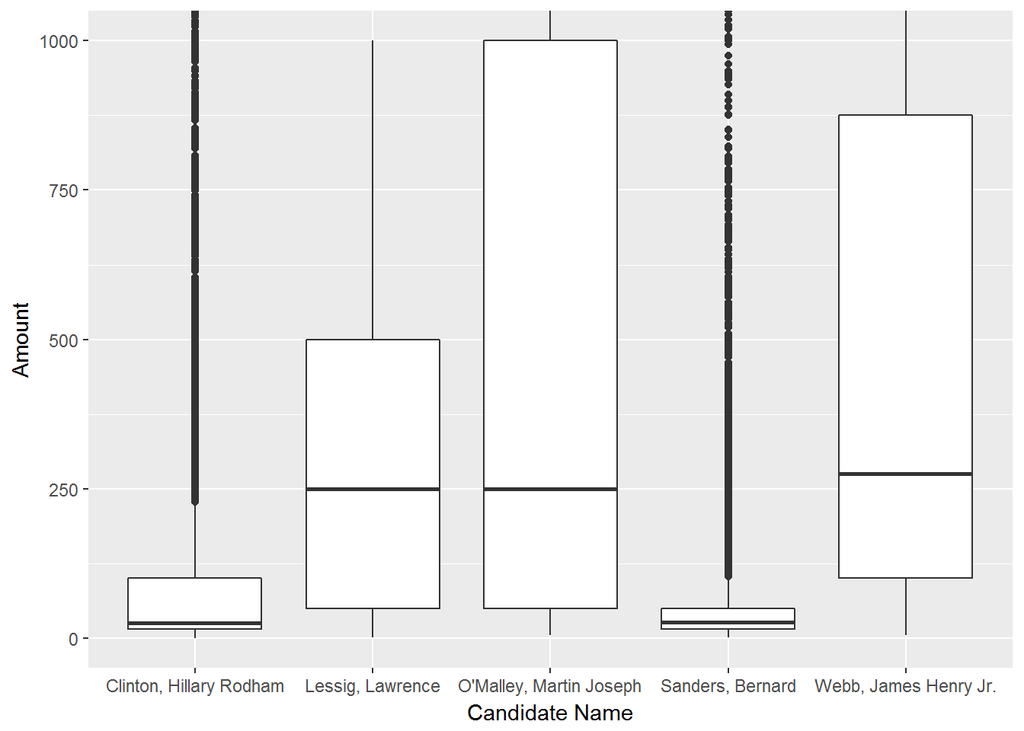

```
## Democratic_Party$cand_nm: Clinton, Hillary Rodham
##     Min.  1st Qu.   Median     Mean  3rd Qu.     Max.
##     0.01    15.00    25.00   139.67   100.00 10000.00
## --------------------------------------------------------
## Democratic_Party$cand_nm: Lessig, Lawrence
##    Min. 1st Qu.  Median    Mean 3rd Qu.    Max.
##       1      50     250     509     500    2700
## --------------------------------------------------------
## Democratic_Party$cand_nm: O'Malley, Martin Joseph
##    Min. 1st Qu.  Median    Mean 3rd Qu.    Max.
##     5.0    50.0   250.0   767.7  1000.0  5400.0
## --------------------------------------------------------
## Democratic_Party$cand_nm: Sanders, Bernard
##     Min.  1st Qu.   Median     Mean  3rd Qu.     Max.
##     1.00    15.00    27.00    51.18    50.00 10000.00
## --------------------------------------------------------
## Democratic_Party$cand_nm: Webb, James Henry Jr.
##    Min. 1st Qu.  Median    Mean 3rd Qu.    Max.
##     5.0   100.0   275.0   722.3   875.0  5400.0
```

It is interesting to note that the candidates who got the most number of donations (from univariate analysis) have the lowest median and mean among all the Democratic Party Candidates. Let’s see if this trend persists for the Republican Party also.

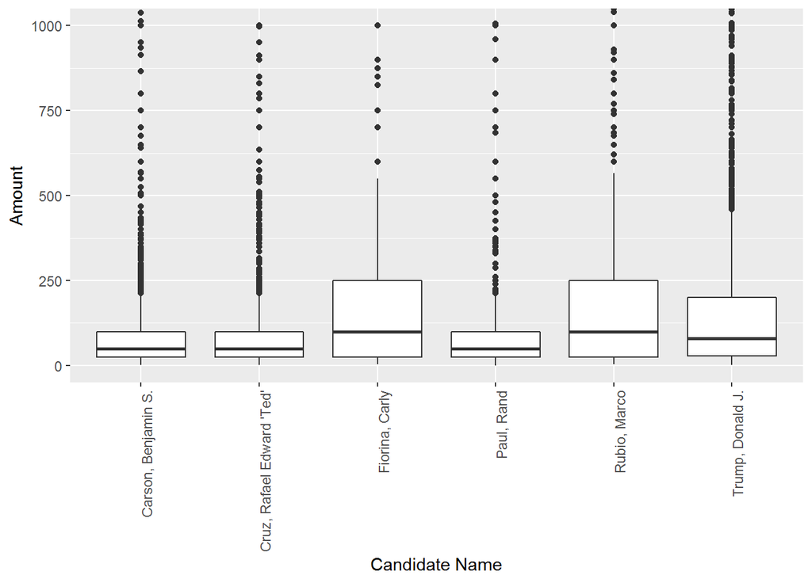

```
## Republican_Party$cand_nm: Carson, Benjamin S.
##    Min. 1st Qu.  Median    Mean 3rd Qu.    Max.
##     1.0    25.0    50.0   123.3   100.0 10000.0
## --------------------------------------------------------
## Republican_Party$cand_nm: Cruz, Rafael Edward 'Ted'
##    Min. 1st Qu.  Median    Mean 3rd Qu.    Max.
##     1.0    25.0    50.0   125.7   100.0 10800.0
## --------------------------------------------------------
## Republican_Party$cand_nm: Fiorina, Carly
##    Min. 1st Qu.  Median    Mean 3rd Qu.    Max.
##     3.0    25.0   100.0   339.2   250.0  5400.0
## --------------------------------------------------------
## Republican_Party$cand_nm: Paul, Rand
##    Min. 1st Qu.  Median    Mean 3rd Qu.    Max.
##    0.01   25.00   50.00  203.22  100.00 5400.00
## --------------------------------------------------------
## Republican_Party$cand_nm: Rubio, Marco
##    Min. 1st Qu.  Median    Mean 3rd Qu.    Max.
##     3.0    25.0   100.0   489.8   250.0  5400.0
## --------------------------------------------------------
## Republican_Party$cand_nm: Trump, Donald J.
##    Min. 1st Qu.  Median    Mean 3rd Qu.    Max.
##     0.8    28.0    80.0   171.6   200.0  5400.0
```

Now, that we have looked at each donation, we will look at the total amount collected by each candidate through these contributions.

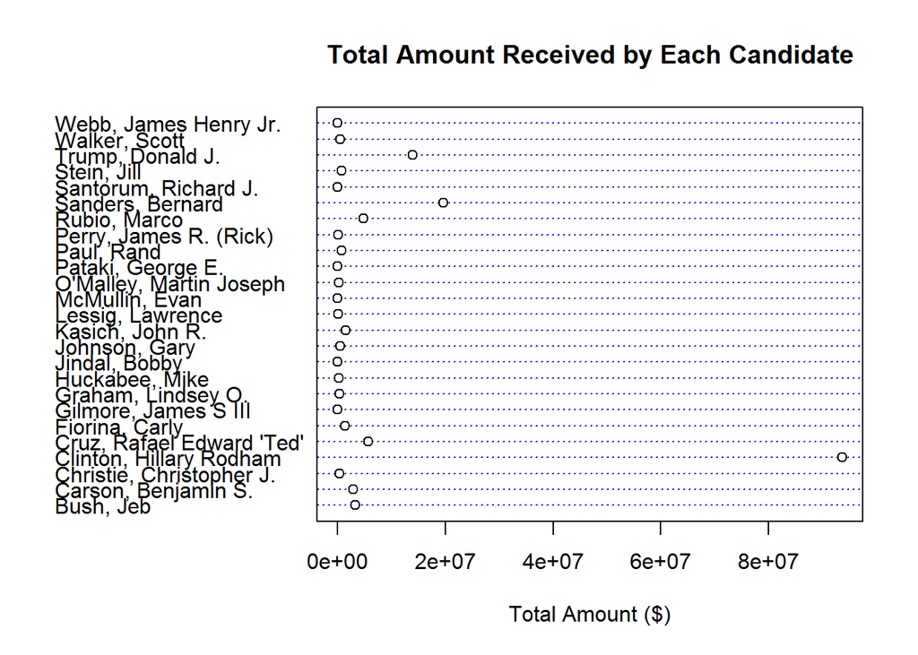

Here, we can see that the two candidates who received the maximum number of donations also, received the highest amounts. However, the total recieved was much greater for one of those candidates than the other.

Thus, lets look at the correlation between the number of donations made and the total amount generated for each candidate.

```
##
##  Pearson's product-moment correlation
##
## data:  by(Data$contb_receipt_amt, Data$cand_nm, sum) and table(Data$cand_nm)
## t = 13.237, df = 23, p-value = 3.046e-12
## alternative hypothesis: true correlation is not equal to 0
## 95 percent confidence interval:
##  0.8672429 0.9736237
## sample estimates:
##       cor
## 0.9401935
```

There appears to be a very high correlation between the total amount generated and the number of donations as shown by the correlation coefficient.

Let’s now look at the amount received by candidates on the dates when maximum donations were made (already calculated in Univariate Section)

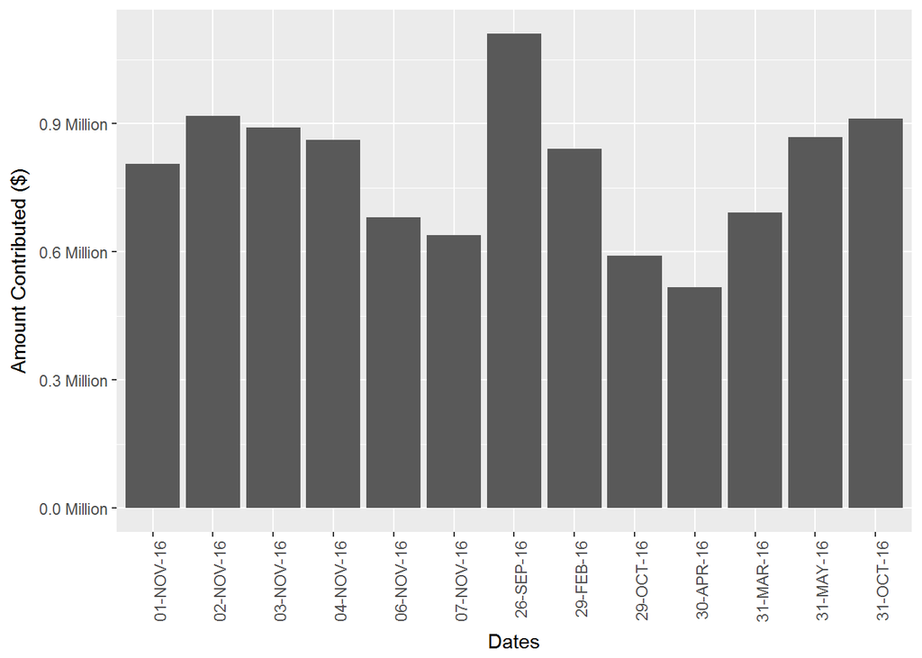

[output not shown]

From the graph and the values above we find that the largest amount was donated on 26th September 2016, around one month before the General Election.

Lets also look at the correlation between the number of donations made each day and the total amount donated that day.

```
##
##  Pearson's product-moment correlation
##
## data:  by(Data$contb_receipt_amt, Data$contb_receipt_dt, sum) and table(Data$contb_receipt_dt)
## t = 38.291, df = 730, p-value < 2.2e-16
## alternative hypothesis: true correlation is not equal to 0
## 95 percent confidence interval:
##  0.7914693 0.8398119
## sample estimates:
##       cor
## 0.8170718
```

We can see that the correlation is quite strong as shown by the Pearson’s Correlation coefficient.

# Bivariate Analysis

### Talk about some of the relationships you observed in this part of the investigation. How did the feature(s) of interest vary with other features in the dataset

Multiple analysis were performed which included studying the relation between gender and amount donated, identifying occupations and employers who have contributed the largest single amounts to the campaigns, the variation in amounts donated depending on the Candidate among each major political party and looking at different correlations between various variables.

It was interesting to see that female candidates, had a higher number of ‘large’ donations compared to their male counter parts. This was mainly due to contributions made toward one candidate (“Clinton, Hillary Rodham”). It was also seen to no surprise that the large contributions came from indivduals who had “high ranking” occupations such as CEO, founder, president, etc. An analysis of the relation between total contributions made and the total amount donated to a particular candidate showed a very strong correlation exhibited by the Pearson Correlation Coefficient.

### Did you observe any interesting relationships between the other features (not the main feature(s) of interest)?

As the main variable being analysed is “contb_receipt_amt” i.e. the amount contributed for each entry, all relations are generated with respect to this variable.

We saw that females generated more money than their male counterparts and having higher contributions would increase your chances of generating greater money. Also, Pearson’s Correlation coefficient suggested that greater the number of donations made in a day, greater is the amount generated.

### What was the strongest relationship you found?

The strongest relation established was the one between the total number of donations made to a candidate and the total amount generated by that candidate.

# Multivariate Plots Section

Let’s first look at the candidate who received the most donation amount and analyze which city contributed the most to this candidate.

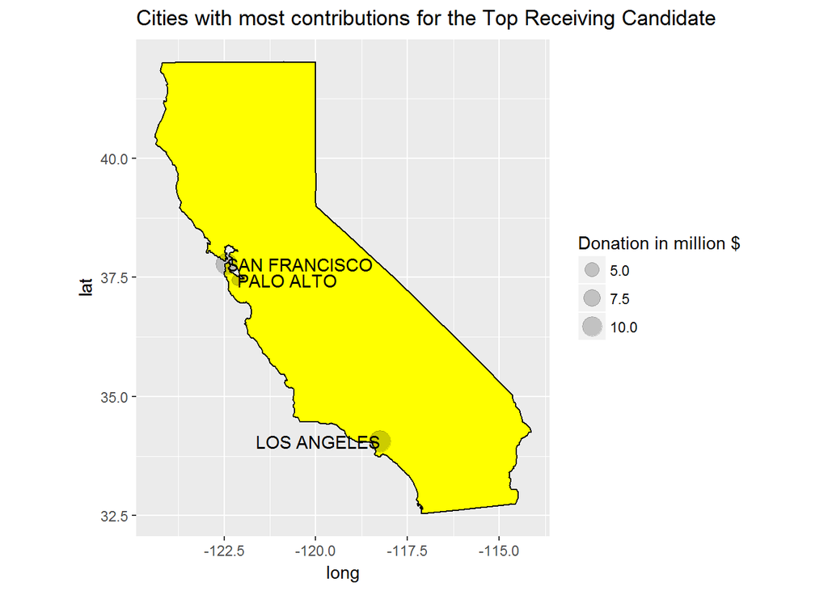

This is very similar to the plot we got in the univariate section when we examined the total contributions made by each city but here, ‘Palo Alto’ replaces ‘San Diego’ as people living here donated more to the top candidate. Let’s also look at the individual amounts that were donated to the top receiving candidate in the top donating cities.

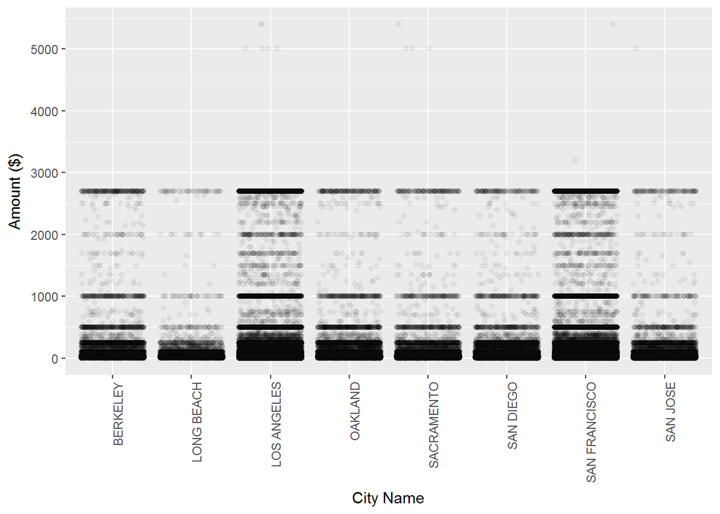

We can see that most of the donations made were $1000 or less, but for the cities of San Francisco and Los Angeles, the amounts donated greater than $1000 were higher compared to the other cities, this contibuted to them donating the most money.

Lets look at the variation in the amount donated per person depending on the employer for the top 5 candidates.

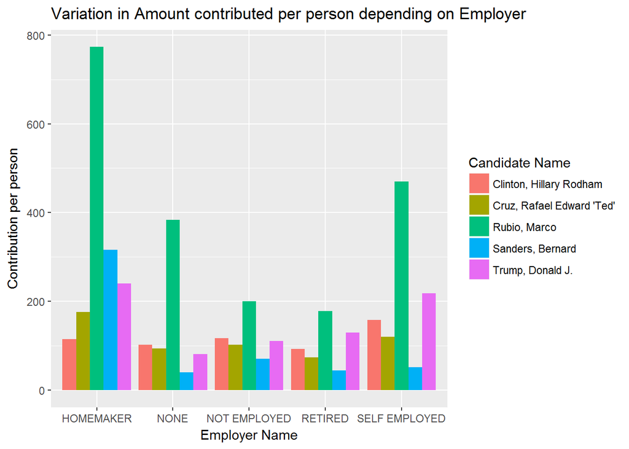

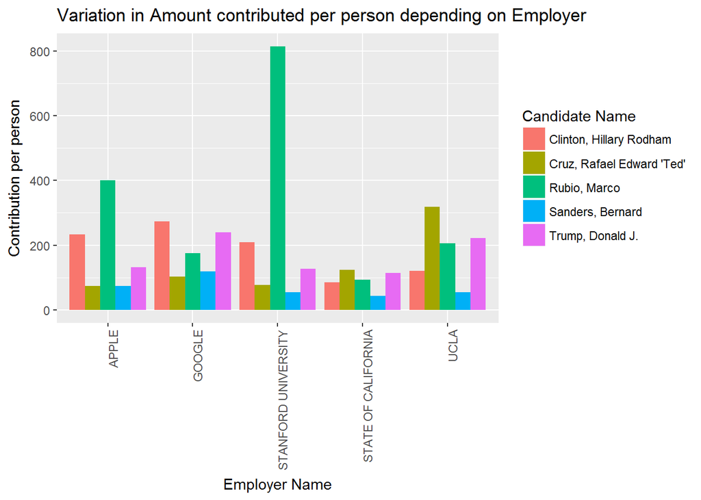

```r
#We will be making two plots, which will make data visualization easier.

#Employers listed on first graph
gp_one <- c("NONE", "HOMEMAKER", "NOT EMPLOYED", "SELF EMPLOYED", "RETIRED")

#Employers listed on second graph
gp_two <- c("APPLE", "GOOGLE", "UCLA", "STATE OF CALIFORNIA",
            "STANFORD UNIVERSITY")

#Candidates receiving most donations, as seen earlier
cand_name_emp <- c("Clinton, Hillary Rodham", "Sanders, Bernard",
                   "Trump, Donald J.","Cruz, Rafael Edward 'Ted'",
                   "Rubio, Marco")

#Function to get the total number of donations per candidate and amount given
#per donation for each employer

get_data <- function(employers, candidates, dataframe){
  cand_employer_data <- ddply(dataframe, c("contbr_employer","cand_nm"),
                              c("nrow"))

  gp_data <- subset(cand_employer_data, contbr_employer %in% employers)
  gp_data <- subset(gp_data, cand_nm %in% candidates)

  sums <- aggregate(Data$contb_receipt_amt,by=list(Data$cand_nm,
                                                 Data$contbr_employer),FUN=sum)
  sums <- subset(sums, (Group.1 %in% candidates)&(Group.2 %in% employers))

  gp_data$per_person <- sums$x/gp_data$nrow
  return (gp_data)
}

gp_one_data <- get_data(gp_one,cand_name_emp, Data)
gp_two_data <- get_data(gp_two,cand_name_emp, Data)
```

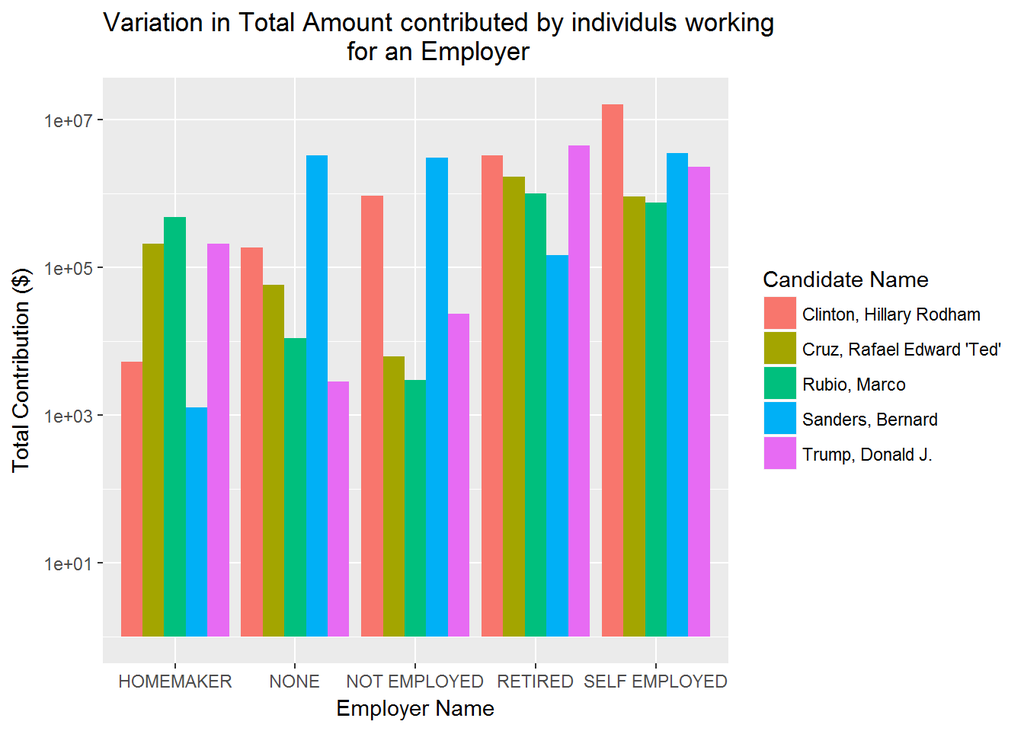

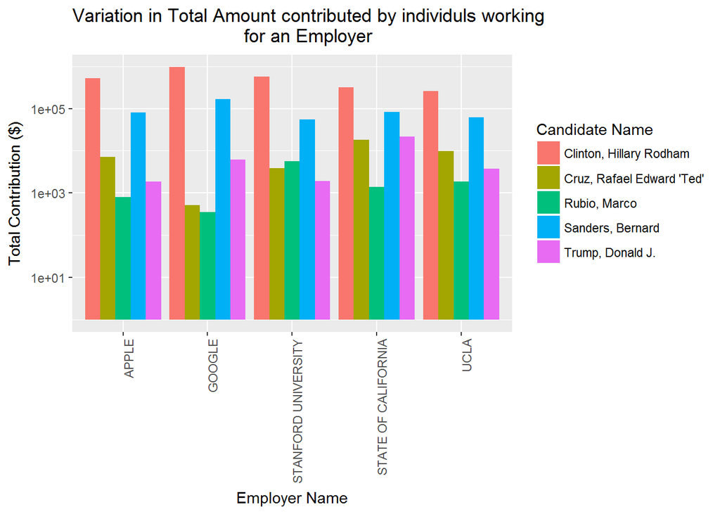

The two graphs give very different results. The second one confirms the hypothesis stated that “Clinton, Hillary Rodham” got the most amount of donations because of her larger number of donations, but in the first plot we see that “Sanders, Bernard”, “Rubio, Marco” and “Trump, Donald J.” received a total greater contribution than “Clinton, Hillary Rodham” for some values.

For these values, lets look at the total contributions made and the average contribution per person,

```
##       contbr_employer                   cand_nm  nrow per_person
## 46953    NOT EMPLOYED   Clinton, Hillary Rodham  7919  117.51124
## 46954    NOT EMPLOYED Cruz, Rafael Edward 'Ted'    61  102.57377
## 46962    NOT EMPLOYED              Rubio, Marco    15  200.60000
## 46963    NOT EMPLOYED          Sanders, Bernard 43307   71.12556
## 46965    NOT EMPLOYED          Trump, Donald J.   213  111.25286
```

```
##       contbr_employer                   cand_nm nrow per_person
## 30560       HOMEMAKER   Clinton, Hillary Rodham   46   114.7598
## 30561       HOMEMAKER Cruz, Rafael Edward 'Ted' 1187   176.5890
## 30570       HOMEMAKER              Rubio, Marco  623   772.8209
## 30571       HOMEMAKER          Sanders, Bernard    4   316.5000
## 30573       HOMEMAKER          Trump, Donald J.  866   240.2656
```

```
##       contbr_employer                   cand_nm  nrow per_person
## 46579            NONE   Clinton, Hillary Rodham  1829  102.63683
## 46580            NONE Cruz, Rafael Edward 'Ted'   620   93.63387
## 46588            NONE              Rubio, Marco    29  383.44828
## 46589            NONE          Sanders, Bernard 80758   40.20742
## 46591            NONE          Trump, Donald J.    35   81.13514
```

```
##       contbr_employer                   cand_nm  nrow per_person
## 54946         RETIRED   Clinton, Hillary Rodham 35443   93.44704
## 54947         RETIRED Cruz, Rafael Edward 'Ted' 23125   73.84675
## 54959         RETIRED              Rubio, Marco  5579  178.64353
## 54960         RETIRED          Sanders, Bernard  3300   44.18255
## 54963         RETIRED          Trump, Donald J. 34207  129.70062
```

For the employee category, “Retired”, we find that although “Clinton, Hillary Rodham” received more number of donations but, “Trump, Donald J.” received the greater total amount because of greater amount donated per person.

# Multivariate Analysis

### Talk about some of the relationships you observed in this part of the investigation. Were there features that strengthened each other in terms of looking at your feature(s) of interest?

Two different analysis were performed here, first we looked at the sources of donations for the top receiving candidate and found that two cities are major contributors to this amount.

The other analysis examined the possiblity of a relation between employers of the donor and the candidate receiving the donation.

# Final Plots and Summary

### Plot One

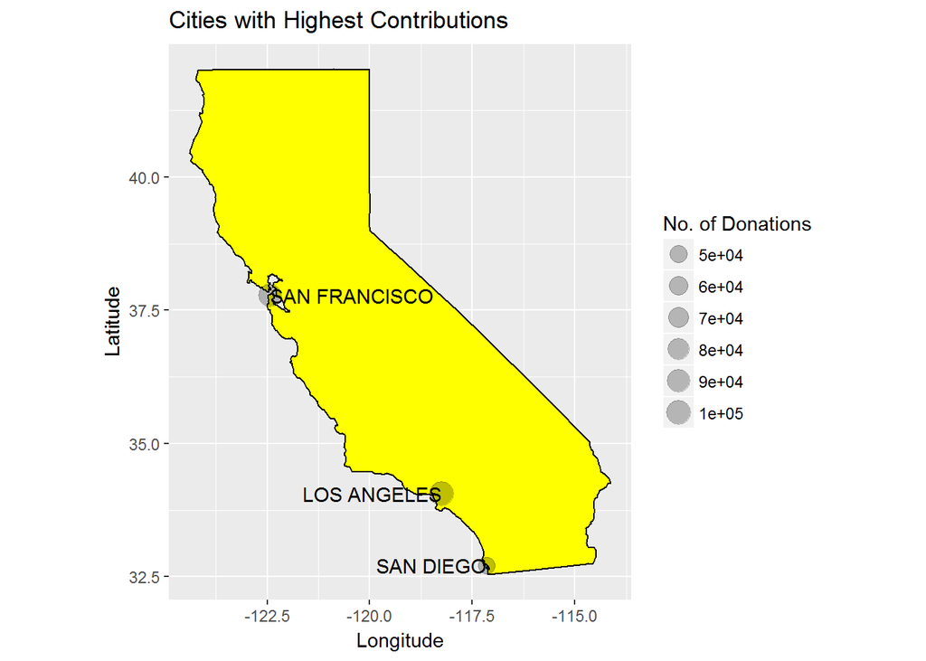

### Description One

This plot looks at the cities from where the maximum donations were received, it can be seen clearly that most of these cities are located along the edges/ coast of the region. This implies that these locations might be densely populated and it makes sense to spend more time and resources campaigning in these cities in the future.

### Plot Two

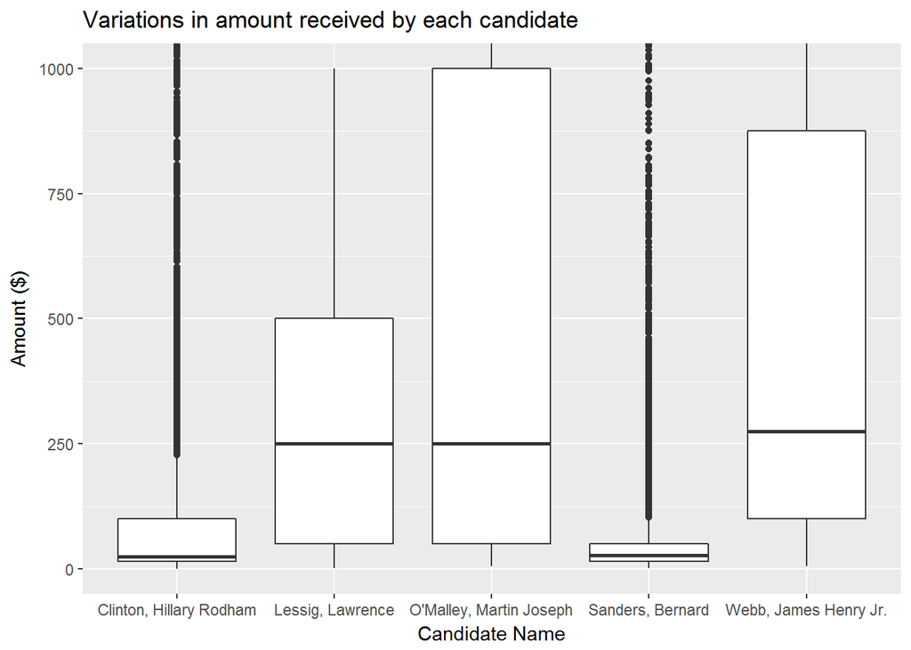

### Plot Three

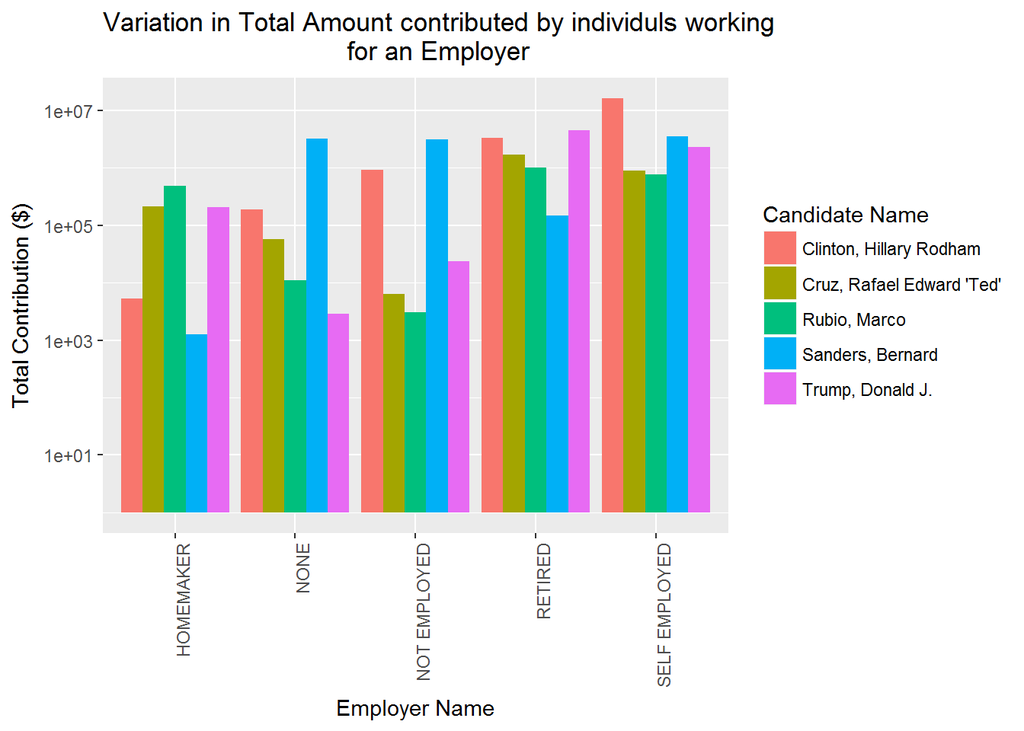

# Reflection

This dataset contained information about the donations received by candidates for the 2016 U.S. Presidential Election from the state of California.

As, there was really only one continous variable in amount donated, analysis revolved around its variation with different groups like political party, candidate name, city of the donor , employer information & occupation of the donor. It was interesting to note that the analysis kept pointing towards a single main leader within the candidates (Clinton, Hillary Rodham) which received the most number and the highest amount of donations.

Variations in the amount donated to candidates revealed that more the number of donations, there is a greater likelihood that the median donation received is lesser. We were also able to identify certain groups that have preferences which are different from the overall trend. This is important for targetting new ‘vote banks’ and generating more funds for the campaign.

This analysis could have been more detailed if, some extra information like age of donors & donor genders was available as candidate preferences vary a lot with age and donor gender might have a bearing on the candidate of choice. The conclusions discussed in the analysis are based on certain assumptions like popularity is a measured by number of donations received by a candidate. Thus, care should be taken while drawing conclusions.

This data could be analysed against the data for the Presidential Election held in 2012 to look at variations in contributions by cities, the differences in dates when these contributions were made and looking at the variation in funds generated between the two major political parties.